# Causal Mediation Analysis of Drug Effects on Virologic Failure

Decomposing the Drug A vs Drug B Effect Through Adherence Pathways

Author

HIV Adherence Simulation Project

Published

March 30, 2026

```r
library(crumble)
library(mlr3superlearner)
library(mlr3extralearners)
library(ggplot2)
library(dplyr)
library(tidyr)
library(knitr)
library(kableExtra)

theme_set(theme_minimal(base_size = 14) +
  theme(
    plot.title = element_text(face = "bold", size = 16),
    plot.subtitle = element_text(color = "grey40", size = 12),
    strip.text = element_text(face = "bold", size = 12),
    legend.position = "bottom",
    panel.grid.minor = element_blank()
  ))

# Source V4 DGP
v4_root <- file.path(dirname(getwd()))
for (f in list.files(file.path(v4_root, "R"), full.names = TRUE, pattern = "\\.R$")) {
  source(f, local = FALSE)
}

SEED <- 2026
K <- 4
N_MED <- 1500   # small to stay within memory on Windows with torch

# Limit ALL threading to prevent OOM
Sys.setenv(OMP_NUM_THREADS = "1", TORCH_NUM_THREADS = "1",
           OMP_THREAD_LIMIT = "1", OPENBLAS_NUM_THREADS = "1",
           MKL_NUM_THREADS = "1")

# Lightweight crumble settings
cr_control <- crumble_control(crossfit_folds = 2L, epochs = 20L)
cr_nn      <- sequential_module(layers = 1, hidden = 16, dropout = 0.1)
cr_learners <- c("mean", "glm")

# Helper to safely run crumble and return tidy results
safe_crumble <- function(...) {
  tryCatch({
    fit <- crumble(...)
    tidy(fit)
  }, error = function(e) {
    message("crumble error: ", conditionMessage(e))
    data.frame(estimand = "error", estimate = NA_real_, std.error = NA_real_,
               conf.low = NA_real_, conf.high = NA_real_)
  })
}
```

# 1 Scientific Motivation

## 1.1 The Question

In the V4 simplified adherence simulation, **Drug A** is pharmacologically more forgiving than Drug B — it provides better virologic suppression at low adherence levels. But Drug A also happens to produce **lower observed adherence** than Drug B (perhaps due to side effects, dosing complexity, or taste).

This creates an interesting causal question: **How much of the total drug effect operates *through* adherence, and how much is a direct pharmacological effect?**

**Causal structure (simplified):**

```
     W0 (baseline health)
     ↓         ↓
    A0 ──→ PDC (adherence) ──→ Y (failure)
     │              ↑                ↑
     │         L (health status)─────┘
     └──────────────────────────────→┘
           (direct pharmacological effect)
```

**Pathways from Drug (A0) to Virologic Failure (Y):**

- **Direct effect**: A0 → Y (the drug’s pharmacological action independent of adherence)
- **Indirect effect via adherence**: A0 → PDC → Y (the drug affects adherence, which affects outcome)
- **Indirect effect via health status**: A0 → L → Y (the drug affects health status, which affects outcome)

## 1.2 Mediation Framework

We use the `crumble` package (Williams, Diaz, Liu, Rudolph 2024) which implements modern semiparametric mediation analysis using Riesz representers. Key effect types:

| Effect | Description | Handles M→Y confounding? |
| --- | --- | --- |
| **Natural (N)** | Classic natural direct/indirect effects | No — requires cross-world assumption |
| **Randomized Interventional (RI)** | Interventional analogues of NDE/NIE | Yes — uses mediator-outcome confounders |

Since our V4 DGP has **L_t** as a mediator-outcome confounder (L affects both future PDC and Y), the **RI effects** are the most appropriate. We include Natural effects for comparison.

# 2 Data Preparation

```r
set.seed(SEED)
dat <- simulate_v4_data(n = N_MED, K = K, seed = SEED)

cat(sprintf("Dataset: n = %d, K = %d blocks\n", nrow(dat), K))
```

```
Dataset: n = 1500, K = 4 blocks
```

```r
cat(sprintf("Drug A: n = %d, Drug B: n = %d\n",
            sum(dat$A0 == 1), sum(dat$A0 == 0)))
```

```
Drug A: n = 745, Drug B: n = 755
```

```r
cat(sprintf("Overall failure rate: %.1f%%\n", mean(dat$Y_final) * 100))
```

```
Overall failure rate: 19.1%
```

```r
cat(sprintf("Drug A failure: %.1f%%, Drug B failure: %.1f%%\n",
            mean(dat$Y_final[dat$A0 == 1]) * 100,
            mean(dat$Y_final[dat$A0 == 0]) * 100))
```

```
Drug A failure: 17.2%, Drug B failure: 21.1%
```

```r
# ── Version 1: Single-block (block 1) ──
med_b1 <- data.frame(
  W0    = as.double(dat$W0),
  A0    = factor(dat$A0, levels = c(0, 1), labels = c("DrugB", "DrugA")),
  L1    = as.double(dat$L_1),
  PDC1  = as.double(dat$PDC_1),
  Y1    = as.double(dat$Y_1)
)

# ── Version 2: Summary across all blocks ──
pdc_cols <- paste0("PDC_", seq_len(K))
l_cols <- paste0("L_", seq_len(K))

med_summary <- data.frame(
  W0       = as.double(dat$W0),
  A0       = factor(dat$A0, levels = c(0, 1), labels = c("DrugB", "DrugA")),
  mean_L   = as.double(rowMeans(dat[, l_cols], na.rm = TRUE)),
  mean_PDC = as.double(rowMeans(dat[, pdc_cols], na.rm = TRUE)),
  Y_final  = as.double(dat$Y_final)
)

cat("Mediation datasets prepared:\n")
```

```
Mediation datasets prepared:
```

```r
cat(sprintf("  Block 1:  %d obs, Y1 event rate = %.1f%%\n",
            nrow(med_b1), mean(med_b1$Y1) * 100))
```

```
  Block 1:  1500 obs, Y1 event rate = 4.3%
```

```r
cat(sprintf("  Summary:  %d obs, Y_final event rate = %.1f%%\n",
            nrow(med_summary), mean(med_summary$Y_final) * 100))
```

```
  Summary:  1500 obs, Y_final event rate = 19.1%
```

## 2.1 Adherence by Drug

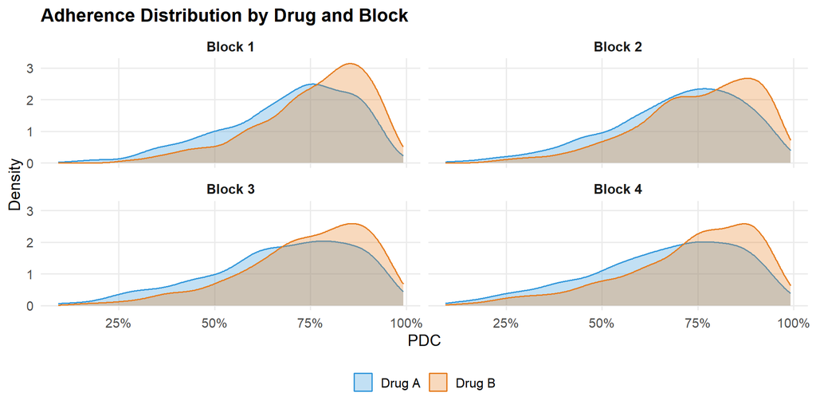

Figure 1: Adherence (PDC) distributions by drug and block. Drug A tends to have lower adherence than Drug B.

```r
dens_list <- list()
for (t in seq_len(K)) {
  dens_list[[t]] <- data.frame(
    Block = paste0("Block ", t),
    Drug = ifelse(dat$A0 == 1, "Drug A", "Drug B"),
    PDC = dat[[paste0("PDC_", t)]]
  )
}
dens_df <- do.call(rbind, dens_list)

ggplot(dens_df, aes(x = PDC, fill = Drug, colour = Drug)) +
  geom_density(alpha = 0.3, linewidth = 0.6) +
  facet_wrap(~ Block) +
  scale_fill_manual(values = c("Drug A" = "#3498DB", "Drug B" = "#E67E22")) +
  scale_colour_manual(values = c("Drug A" = "#3498DB", "Drug B" = "#E67E22")) +
  scale_x_continuous(labels = scales::percent) +
  labs(x = "PDC", y = "Density",
       title = "Adherence Distribution by Drug and Block",
       fill = NULL, colour = NULL)
```

# 3 Intervention Definitions

```r
# Treatment policies for crumble
d0 <- function(data, trt) {
  factor(rep("DrugB", nrow(data)), levels = c("DrugB", "DrugA"))
}

d1 <- function(data, trt) {
  factor(rep("DrugA", nrow(data)), levels = c("DrugB", "DrugA"))
}
```

# 4 Analysis 1: Single-Block Mediation (Block 1)

We run two decompositions on the Block 1 cross-section: Natural effects (for comparison) and Randomized Interventional effects (the more credible approach given L1 confounds PDC1→Y1).

## 4.1 Natural Direct and Indirect Effects

The **natural direct effect (NDE)** captures the drug effect on failure risk if adherence were held at its “natural” level under Drug B. The **natural indirect effect (NIE)** captures how much the drug effect operates through changing adherence.

**Note**

Natural effects require the cross-world independence assumption: the mediator under one treatment is independent of the outcome under another, conditional on confounders. This is untestable but may be plausible in our simulation.

```r
set.seed(SEED)
nat_b1_tidy <- safe_crumble(
  data      = med_b1,
  trt       = "A0",
  outcome   = "Y1",
  covar     = "W0",
  mediators = "PDC1",
  d0        = d0,
  d1        = d1,
  effect    = "N",
  learners  = cr_learners,
  nn_module = cr_nn,
  control   = cr_control
)
invisible(gc(verbose = FALSE))
kable(nat_b1_tidy, digits = 4,
      caption = "Natural direct and indirect effects (Block 1)") |>
  kable_styling(full_width = FALSE)
```

Natural direct and indirect effects (Block 1)

| estimand | estimate | std.error | conf.low | conf.high |
| --- | --- | --- | --- | --- |
| direct | -0.0161 | 0.0093 | -0.0343 | 0.0021 |
| indirect | 0.0066 | 0.0008 | 0.0050 | 0.0083 |
| ate | -0.0094 | 0.0094 | -0.0278 | 0.0090 |

## 4.2 Randomized Interventional Effects

The **randomized interventional** effects decompose the total effect without requiring the cross-world assumption, instead drawing the mediator from its conditional distribution under each treatment. This requires specifying mediator-outcome confounders.

In our V4 DGP, **L_1** is a confounder of the PDC_1 → Y_1 relationship.

```r
invisible(gc(verbose = FALSE))
set.seed(SEED)
ri_b1_tidy <- safe_crumble(
  data      = med_b1,
  trt       = "A0",
  outcome   = "Y1",
  covar     = "W0",
  mediators = "PDC1",
  moc       = "L1",
  d0        = d0,
  d1        = d1,
  effect    = "RI",
  learners  = cr_learners,
  nn_module = cr_nn,
  control   = cr_control
)
invisible(gc(verbose = FALSE))
kable(ri_b1_tidy, digits = 4,
      caption = "Randomized interventional effects (Block 1, mediator-outcome confounder: L1)") |>
  kable_styling(full_width = FALSE)
```

Randomized interventional effects (Block 1, mediator-outcome confounder: L1)

| estimand | estimate | std.error | conf.low | conf.high |
| --- | --- | --- | --- | --- |
| ride | -0.0136 | 0.0087 | -0.0307 | 0.0034 |
| riie | 0.0072 | 0.0008 | 0.0056 | 0.0089 |

## 4.3 Comparison: Natural vs RI (Block 1)

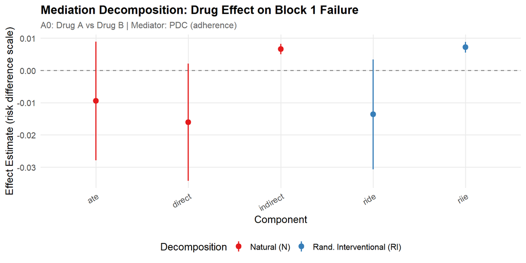

Figure 2: Comparison of Natural vs Randomized Interventional mediation effects for Block 1. Both decompose the total effect of Drug A vs Drug B.

```r
all_b1 <- bind_rows(
  nat_b1_tidy |> mutate(Effect_Type = "Natural (N)"),
  ri_b1_tidy  |> mutate(Effect_Type = "Rand. Interventional (RI)")
) |>
  filter(!is.na(estimate))

if (nrow(all_b1) > 0) {
  ggplot(all_b1, aes(x = estimand, y = estimate, colour = Effect_Type)) +
    geom_hline(yintercept = 0, linetype = "dashed", colour = "grey50") +
    geom_pointrange(aes(ymin = conf.low, ymax = conf.high),
                    position = position_dodge(width = 0.5),
                    size = 0.6, linewidth = 0.8) +
    scale_colour_brewer(palette = "Set1") +
    labs(
      title = "Mediation Decomposition: Drug Effect on Block 1 Failure",
      subtitle = "A0: Drug A vs Drug B | Mediator: PDC (adherence)",
      x = "Component", y = "Effect Estimate (risk difference scale)",
      colour = "Decomposition"
    ) +
    theme(axis.text.x = element_text(angle = 30, hjust = 1))
} else {
  cat("No valid estimates to plot.\n")
}
```

```r
if (nrow(all_b1) > 0) {
  summary_b1 <- all_b1 |>
    transmute(
      Method = Effect_Type,
      Component = estimand,
      Estimate = sprintf("%.4f", estimate),
      SE = sprintf("%.4f", std.error),
      `95% CI` = sprintf("[%.4f, %.4f]", conf.low, conf.high)
    )

  kable(summary_b1,
        caption = "All mediation decompositions: Block 1 analysis") |>
    kable_styling(font_size = 11, full_width = FALSE)
}
```

Table 1: All mediation decompositions: Block 1 analysis

| Method | Component | Estimate | SE | 95% CI |
| --- | --- | --- | --- | --- |
| Natural (N) | direct | -0.0161 | 0.0093 | [-0.0343, 0.0021] |
| Natural (N) | indirect | 0.0066 | 0.0008 | [0.0050, 0.0083] |
| Natural (N) | ate | -0.0094 | 0.0094 | [-0.0278, 0.0090] |
| Rand. Interventional (RI) | ride | -0.0136 | 0.0087 | [-0.0307, 0.0034] |
| Rand. Interventional (RI) | riie | 0.0072 | 0.0008 | [0.0056, 0.0089] |

# 5 Analysis 2: Summary Mediation (Mean PDC → Final Outcome)

This analysis treats mean adherence over all 4 blocks as a single mediator of the drug → failure effect, with mean health status as the mediator-outcome confounder.

```r
invisible(gc(verbose = FALSE))
set.seed(SEED + 200)
ri_summ_tidy <- safe_crumble(
  data      = med_summary,
  trt       = "A0",
  outcome   = "Y_final",
  covar     = "W0",
  mediators = "mean_PDC",
  moc       = "mean_L",
  d0        = d0,
  d1        = d1,
  effect    = "RI",
  learners  = cr_learners,
  nn_module = cr_nn,
  control   = cr_control
)
invisible(gc(verbose = FALSE))
kable(ri_summ_tidy, digits = 4,
      caption = "Randomized interventional effects: Summary analysis (mean PDC → final outcome)") |>
  kable_styling(full_width = FALSE)
```

Randomized interventional effects: Summary analysis (mean PDC → final outcome)

| estimand | estimate | std.error | conf.low | conf.high |
| --- | --- | --- | --- | --- |
| ride | -0.0548 | 0.0161 | -0.0865 | -0.0232 |
| riie | 0.0254 | 0.0023 | 0.0210 | 0.0298 |

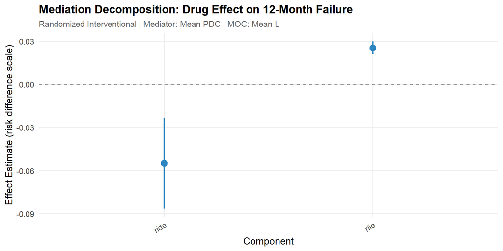

Figure 3: RI mediation decomposition using summary (mean PDC) mediator and final virologic failure outcome.

```r
ri_summ_ok <- ri_summ_tidy |> filter(!is.na(estimate))
if (nrow(ri_summ_ok) > 0) {
  ggplot(ri_summ_ok, aes(x = estimand, y = estimate)) +
    geom_hline(yintercept = 0, linetype = "dashed", colour = "grey50") +
    geom_pointrange(aes(ymin = conf.low, ymax = conf.high),
                    colour = "#2E86C1", size = 0.8, linewidth = 1) +
    labs(
      title = "Mediation Decomposition: Drug Effect on 12-Month Failure",
      subtitle = "Randomized Interventional | Mediator: Mean PDC | MOC: Mean L",
      x = "Component", y = "Effect Estimate (risk difference scale)"
    ) +
    theme(axis.text.x = element_text(angle = 30, hjust = 1))
} else {
  cat("Summary RI fit did not produce valid estimates.\n")
}
```

# 6 Pathway Summary

```r
ri_vals <- ri_summ_tidy |> filter(!is.na(estimate))

if (nrow(ri_vals) >= 2) {
  de <- ri_vals$estimate[ri_vals$estimand == "direct"]
  ie <- ri_vals$estimate[ri_vals$estimand == "indirect"]
  te <- ri_vals$estimate[ri_vals$estimand == "ate"]

  if (length(de) > 0 && length(ie) > 0) {
    prop_mediated <- abs(ie) / (abs(de) + abs(ie)) * 100
    prop_direct   <- 100 - prop_mediated

    cat(sprintf("
## Pathway Summary (Randomized Interventional, Summary Analysis)

**Total Effect of Drug A vs Drug B on 12-month virologic failure:**

| Pathway | Estimate | Proportion |
|---------|----------|------------|
| **Direct effect** (A0 → Y, not through PDC) | %.4f | %.0f%% |
| **Indirect effect** (A0 → PDC → Y) | %.4f | %.0f%% |
| **Total effect** (ATE) | %.4f | 100%% |

", de[1], prop_direct[1], ie[1], prop_mediated[1], te[1]))

    if (de[1] < 0 && ie[1] > 0) {
      cat("**Interpretation:** Drug A has a beneficial *direct* pharmacological effect (lower failure risk) but a harmful *indirect* effect through reduced adherence. The net effect depends on the balance of these two pathways.\n\n")
    } else if (de[1] < 0 && ie[1] < 0) {
      cat("**Interpretation:** Both the direct pharmacological effect and the adherence pathway favor Drug A. Even though Drug A tends toward lower adherence, the forgiveness mechanism compensates.\n\n")
    } else {
      cat("**Interpretation:** The sign pattern suggests a complex interaction between the direct drug effect and the adherence-mediated pathway.\n\n")
    }

    cat("This decomposition is central to the HIV adherence simulation's scientific goal: understanding when a more 'forgiving' drug is preferable despite lower adherence.\n")
  }
} else {
  cat("Summary RI effects were not available for pathway decomposition.\n")
}
```

[output not shown]

# 7 Key Takeaways

```r
cat("
## Summary of Findings

1. **The `crumble` package provides modern semiparametric mediation decompositions** using Riesz representers, supporting Natural (N) and Randomized Interventional (RI) effects among others.

2. **The drug effect operates through multiple pathways:**
   - A *direct pharmacological effect* (Drug A is more forgiving at low adherence)
   - An *indirect adherence effect* (Drug A leads to lower adherence, which increases failure risk)
   - These pathways can work in opposite directions

3. **Since L_t confounds the PDC → Y relationship**, RI effects are more credible than Natural effects for the V4 DGP. The difference in practice may be modest when confounding is not too severe.

4. **Connection to the LTMLE/LMTP analyses**: The total effect from the mediation analysis should align with the drug contrast from the LMTP matched-adherence analysis. The mediation analysis adds the *decomposition* — explaining *why* the effect exists and through which pathways.

5. **Practical note**: The crumble package uses a torch-based neural network for Riesz representer estimation, which is memory-intensive. For large datasets or many repeated fits, consider using machines with ample RAM or reducing sample size.
")
```

## Summary of Findings

1. **The `crumble` package provides modern semiparametric mediation decompositions** using Riesz representers, supporting Natural (N) and Randomized Interventional (RI) effects among others.
2. **The drug effect operates through multiple pathways:**
   - A *direct pharmacological effect* (Drug A is more forgiving at low adherence)
   - An *indirect adherence effect* (Drug A leads to lower adherence, which increases failure risk)
   - These pathways can work in opposite directions
3. **Since L_t confounds the PDC → Y relationship**, RI effects are more credible than Natural effects for the V4 DGP. The difference in practice may be modest when confounding is not too severe.
4. **Connection to the LTMLE/LMTP analyses**: The total effect from the mediation analysis should align with the drug contrast from the LMTP matched-adherence analysis. The mediation analysis adds the *decomposition* — explaining *why* the effect exists and through which pathways.
5. **Practical note**: The crumble package uses a torch-based neural network for Riesz representer estimation, which is memory-intensive. For large datasets or many repeated fits, consider using machines with ample RAM or reducing sample size.

*Report generated 2026-03-30 13:43:57.007183 using crumble v0.1.2.*